# GLM for Data With Non-Normal Distributions: Binary and Binomial Data

Hector 2015 Chapter 9

We introduced GLMs in Chapter 8. The key advance over least squares linear models is that we can use the link and variance functions to model the mean and variability separately.

In our analysis of the timber hardness data we used a square-root link function to linearize the relationship and the gamma distribution to model the way in which the variance increased as a function of the mean.

**Binary Data**: yes/no, live/die, pass/fail

GLMs are probably most useful with binary data (since no transformation can make the residuals normal and least squares methods are useless).

**Count Data**: whole integers; 0, 1, 2, 3 etc. and **binomial count**; eight deaths from twelve organisms (8 failures, 4 successes)

We will begin with a small data set from an experiment looking at the mortality of batches of the flour beetle *Tribolium confusa* exposed to different doses of a pesticide.

```r
data(beetle) # from AICcmodavg
beetle$Number_survived <- beetle$Number_tested - beetle$Number_killed
```

When binomial count data are expressed as proportions the mean must asymptote towards zero (the minimum possible value) and one (the maximum), and this floor and ceiling also constrain the variance. This means we would expect to need some sort of ‘S-shaped’ relationship to model the mean while the variance will decrease towards both extremes (0,1) and be greatest in between.

The default (canonical) link function in binomial GLMs is the logistic transformation.

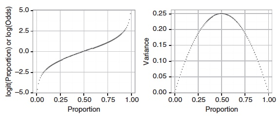

The logistic transformation converts proportions to logits. Logits are the natural log of the odds and the odds are the ratio of successes to failures. If we had a binomial denominator of ten with five successes to five failures then the logit would be log(5/5) = 0.

So why not simply use the logit transformation and analyse the resulting logits with a normal least squares regression? Because the variance is not constant: as we said it is larger at intermediate proportions and decreases towards both extremes. Instead we use a binomial variance function to model the variability.

We use the **family** argument to specify the **binomial** distribution (for which the logistic is the default link function). The logistic link function and binomial distribution take account of the properties and constraints on the pattern of the mean and variance for binomial count data.

```r
m1 <- glm(cbind(Number_killed, Number_survived) ~ Dose, data= beetle, family= binomial)
#wr <- glm(Mortality_rate~Dose, data= beetle, family= binomial, weight= Number_tested)
#alternative by weighted regression
```

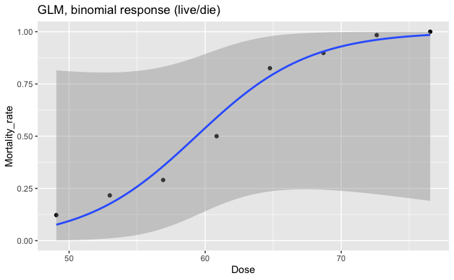

```r
ggplot(beetle,aes(Dose,Mortality_rate)) +geom_point() +
  geom_smooth(method="glm", method.args=list(family="binomial"(link="logit")))+
  labs(title="GLM, binomial response (live/die)")
```

The proportion of beetles killed (Mortality rate) as a function of increasing concentration of carbon disulphide (Dose).The CI for the slope does not contain zero, supporting an increasing probability of mortality as dose increases, as we would expect.

```r
coef(m1)
```

```
(Intercept)        Dose
-14.5780604   0.2455399
```

```r
confint(m1)
```

```
                  2.5 %      97.5 %
(Intercept) -17.2645230 -12.1608424
Dose          0.2056099   0.2900912
```

```r
summary(m1)
```

```
Call:
glm(formula = cbind(Number_killed, Number_survived) ~ Dose, family = binomial,
    data = beetle)

Deviance Residuals:
    Min       1Q   Median       3Q      Max
-1.3456  -0.4515   0.7929   1.0422   1.3262

Coefficients:
             Estimate Std. Error z value Pr(>|z|)
(Intercept) -14.57806    1.29846  -11.23   <2e-16 ***
Dose          0.24554    0.02149   11.42   <2e-16 ***
---
Signif. codes:  0 ‘***’ 0.001 ‘**’ 0.01 ‘*’ 0.05 ‘.’ 0.1 ‘ ’ 1

(Dispersion parameter for binomial family taken to be 1)

    Null deviance: 267.6624  on 7  degrees of freedom
Residual deviance:   8.4379  on 6  degrees of freedom
AIC: 38.613

Number of Fisher Scoring iterations: 4
```

This overdispersion is not too substantial but we can account for it by using the closely related approach of quasi-maximum likelihood. If we alter the family to **quasi-binomial** then instead of being assumed (and underestimated), the level of variation will be estimated from the data and the standard errors increased accordingly.

```r
mq1 <- glm(cbind(Number_survived, Number_killed) ~ Dose, data= beetle, quasibinomial)
summary(mq1)
```

```
Call:
glm(formula = cbind(Number_survived, Number_killed) ~ Dose, family = quasibinomial,
    data = beetle)

Deviance Residuals:
    Min       1Q   Median       3Q      Max
-1.3262  -1.0422  -0.7929   0.4515   1.3456

Coefficients:
            Estimate Std. Error t value Pr(>|t|)
(Intercept) 14.57806    1.46611   9.943 5.98e-05 ***
Dose        -0.24554    0.02427 -10.118 5.42e-05 ***
---
Signif. codes:  0 ‘***’ 0.001 ‘**’ 0.01 ‘*’ 0.05 ‘.’ 0.1 ‘ ’ 1

(Dispersion parameter for quasibinomial family taken to be 1.274895)

    Null deviance: 267.6624  on 7  degrees of freedom
Residual deviance:   8.4379  on 6  degrees of freedom
AIC: NA

Number of Fisher Scoring iterations: 4
```

Notice how the standard errors of the quasibinomial are increased compared with those from the binomial GLM to take account of the overdispersion.

However, one disadvantage of quasi-maximum likelihood is that because we have a quasi-likelihood rather than a true likelihood we are not given a value for the Akaike information criterion (AIC; although, as we will see later, some statisticians are willing to calculate quasi-AIC values and there are R packages that provide them, including the `AICcmodavg` package used here).

**Summary: Binomial Count Data**

- use of the `glm()` function for analysing binomial count data illustrated how we have to bind together the successes and failures for the response variable and specify the binomial distribution using the family argument.
- We can check whether the level of variability is as assumed by the binomial distribution model and inflate the standard errors to account for any overdispersion using a quasi-maximum likelihood approach.

**Binary Data**

Binary data are an extreme form of binomial count data in which the binomial denominator is equal to one, so that every trial produces a value of either one or zero. Binary data can therefore be analysed using a GLM with a binomial distribution and the same choice of link functions to prevent predictions going below zero or above values of one.

However, despite the use of the same distribution and link functions, because of the constrained nature of the data there are some differences in the analysis of binomial counts. For one thing, the use of the ratio of the residual deviance to residual DF to diagnose over- or underdispersion does not apply. We use `arm` package `binnedplot()` function instead for model checking.

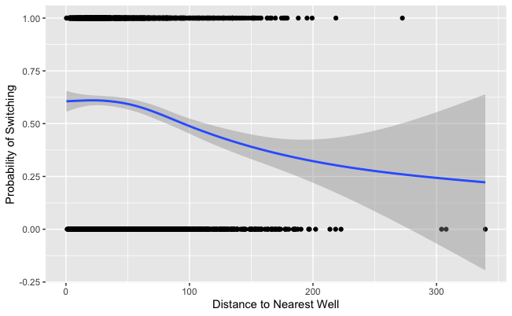

```r
wells <- read.delim("Binary_Wells.txt")
ggplot(wells,aes(dist,switch)) +geom_point() +
  geom_smooth() +
  xlab ("Distance to Nearest Well") +
  ylab ("Probability of Switching")
```

It looks like the probability of switching declines with distance, as we would expect (Fig. 9.2). Before we fit the GLM we can avoid inconveniently small coefficient values by rescaling distance in hundreds of meters.

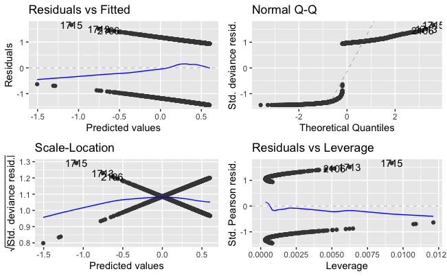

```r
wells$dist100 <- wells$dist/100
fit.1 <- glm(switch~dist100, data=wells, binomial(link="logit"))
autoplot(fit.1)
```

The logistic link function is the default for the binomial variance function. With a normal least squares analysis we could use the automatic diagnostic plots to examine the residuals but **the constrained nature of binary data makes them of little if any use** (Fig. 9.3).

As already mentioned, we cannot use the ratio of the residual deviance to residual DF to look for overdispersion as we do with binomial counts (and Poisson GLMs). Luckily the `arm` package provides the `binnedplot()` function that offers a graphical approach.

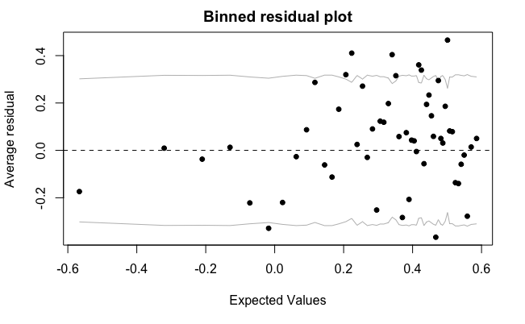

```r
library(arm)
x <- predict(fit.1)
y <- resid(fit.1)
binnedplot(x, y)
```

The grey lines in the plot indicate ±2 standard errors, within which approximately 95% of the binned residuals are expected to fall.

```r
coef(fit.1)
```

```
(Intercept)     dist100
  0.6059594  -0.6218819
```

```r
confint(fit.1)
```

```
                 2.5 %     97.5 %
(Intercept)  0.4882230  0.7246814
dist100     -0.8140762 -0.4319795
```

It does indeed seem to be the case that the further away an alternative well is, the less likely people are to switch to it.

Gelman and Hill promote a rough rule of thumb for interpreting the slope of the logistic regression: the ‘divide by four rule’. Dividing the coefficient for the logistic regression slope by four will give us an approximate estimate for the maximum predicted effect on the response of a unit change in the predictor.

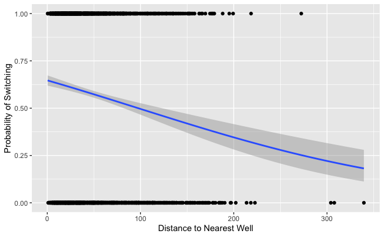

```r
ggplot(wells, aes(dist,switch)) +
         geom_point() +
         geom_smooth(method="glm", method.args=list(family="binomial"(link="logit"))) +
         xlab ("Distance to Nearest Well") +
         ylab ("Probability of Switching")
```

We can look at the effect of arsenic concentration in a similar way:

```r
fit.2 <- glm(switch~arsenic, binomial(link="logit"), data= wells)
display(fit.2)
```

[output not shown]

Once again, the estimates are in logits with a clear positive effect of increasing arsenic concentration on the probability of switching wells, as expected.

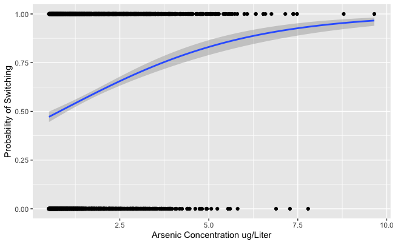

```r
ggplot(wells, aes(arsenic,switch)) +
         geom_point() +
         geom_smooth(method="glm", method.args=list(family="binomial"(link="logit"))) +
         xlab ("Arsenic Concentration ug/Liter") +
         ylab ("Probability of Switching")
```

Lets look at **Arsenic concentration** AND **Distance to a Safe Well** in the same model; this way we can also test for interaction effects to see if there is a trade off.

Before fitting the GLM we can make life easier by *centering the explanatory variables by subtracting their mean value*. This has advantages when a regression intercept of zero is unhelpful or makes no sense (as with a distance of zero meters here—if we took this literally the new and old well would be in the same place) and when examining interactions:

```r
wells$c.dist100 <- wells$dist100 - mean(wells$dist100)
wells$c.arsenic <- wells$arsenic - mean(wells$arsenic)
fit.5 <- glm(switch~c.dist100+c.arsenic+c.dist100:c.arsenic,
binomial, data= wells)
display(fit.5) # model numbering from Gelman and Hill
```

```
glm(formula = switch ~ c.dist100 + c.arsenic + c.dist100:c.arsenic,
    family = binomial, data = wells)
                    coef.est coef.se
(Intercept)          0.35     0.04
c.dist100           -0.87     0.10
c.arsenic            0.47     0.04
c.dist100:c.arsenic -0.18     0.10
---
  n = 3020, k = 4
  residual deviance = 3927.6, null deviance = 4118.1 (difference = 190.5)
```

The coefficients are all given on the **logit scale**. Back-transforming the estimate for the intercept (using the invlogit() function displayed below) gives the probability of switching—because we have centred both variables this is the probability of switching at average arsenic levels and average distance to the nearest safe well:

```r
invlogit <- function(x) {1 / ( 1+exp(-x) ) }
invlogit(coef(fit.5))[1]
```

```
(Intercept)
  0.5868829
```

The probability of switching at average arsenic levels and average distance to the nearest safe well is 0.5868829.

**c.dist100** The effect of a change of 100 m when arsenic is at average levels is **-0.87**.

**c.arsenic** The effect of a unit change (1 ug/L) in arsenic for a well at average distance is *0.47**.

So far we have focused on effect sizes (intercepts and slopes), but what about P-values?

The size of the estimated difference (–0.18) for the interaction is a bit less than twice the standard error of the difference (0.1), so while it is marginally significant it fails to meet the conventional 5% level (as you can explore using the `confint()` function CIs, the `summary()` function Z-values, or the likelihood ratio test produced by applying the `anova()` function to a pair of models with and without the interaction).

```r
confint(fit.5)
```

```
                         2.5 %      97.5 %
(Intercept)          0.2732603  0.42951145
c.dist100           -1.0808894 -0.66992679
c.arsenic            0.3882846  0.55325092
c.dist100:c.arsenic -0.3795821  0.02232171
```

```r
summary(fit.5)
```

```
Call:
glm(formula = switch ~ c.dist100 + c.arsenic + c.dist100:c.arsenic,
    family = binomial, data = wells)

Deviance Residuals:
    Min       1Q   Median       3Q      Max
-2.7823  -1.2004   0.7696   1.0816   1.8476

Coefficients:
                    Estimate Std. Error z value Pr(>|z|)
(Intercept)          0.35109    0.03985   8.810   <2e-16 ***
c.dist100           -0.87365    0.10480  -8.337   <2e-16 ***
c.arsenic            0.46951    0.04207  11.159   <2e-16 ***
c.dist100:c.arsenic -0.17891    0.10233  -1.748   0.0804 .
---
Signif. codes:  0 ‘***’ 0.001 ‘**’ 0.01 ‘*’ 0.05 ‘.’ 0.1 ‘ ’ 1

(Dispersion parameter for binomial family taken to be 1)

    Null deviance: 4118.1  on 3019  degrees of freedom
Residual deviance: 3927.6  on 3016  degrees of freedom
AIC: 3935.6

Number of Fisher Scoring iterations: 4
```

**Summary: Binary Data**